# PART A: Box Plots

#### Create a new dataset with standardized and augmented data

```python
df_interacBest_std = indep_var.copy()
df_interacBest_std.insert(0, 'cases', dep_var)
```

```python
df_interacBest_std.head()
```

|  | cases | Urban_pop_proportion_std | Urban_Nurse_std | Mean_Nurse_std | Nurse_midwife_per_1000_2009to18_std | Mean_year_of_schooling_std | Specialist_surgical_workforce_std | Mean_Specialist_std | Urban_Physicians_std | Nurse_GNI_std | Expected_GNI_std | Expected_Mean_std | Urban_GNI_std | Expected_year_of_schooling_std | Physicians_Specialist_std | Expected_Nurse_std | HDI_GNI_std | Mean_HDI_std | Nurse_Pysicians_std | Urban_Specialist_std |
| --- | --- | --- | --- | --- | --- | --- | --- | --- | --- | --- | --- | --- | --- | --- | --- | --- | --- | --- | --- | --- |
| 0 | 6402 | -1.382215 | 0.764957 | 0.413415 | -0.887187 | -1.290265 | -0.790153 | 0.252310 | 0.446300 | 0.075398 | 0.115575 | 0.307196 | 0.257303 | -0.855108 | -0.175312 | 0.186349 | 0.137623 | 0.680020 | -0.045698 | 0.756859 |
| 1 | 933 | 0.431833 | -0.315203 | -0.508301 | 0.268212 | 0.739439 | -0.440228 | -0.984015 | -0.575541 | -0.360389 | -0.634975 | -0.134228 | -0.331829 | 0.896001 | -0.491558 | -0.345144 | -0.508482 | -0.264475 | -0.543394 | -0.810276 |
| 2 | 6821 | 0.909213 | -0.624166 | -0.719768 | -0.221957 | 0.084696 | -0.425146 | -0.717899 | -0.255799 | -0.396023 | -0.505312 | -0.735242 | -0.241349 | 0.736809 | -0.598156 | -0.759265 | -0.441053 | -0.896807 | -0.574076 | -1.050361 |
| 6 | 7805 | 1.863975 | -0.576376 | -0.757836 | -0.081909 | 0.706702 | 0.721159 | -0.216345 | 2.799624 | -0.398132 | 0.656394 | 0.568727 | 0.259093 | 1.930747 | 0.272921 | -0.753733 | -0.045092 | -0.078114 | -0.634088 | 1.064918 |
| 7 | 4283 | 0.431833 | -0.021067 | 0.520920 | 0.968453 | 1.295971 | 1.825231 | 1.489473 | -0.080481 | -0.480298 | -0.719466 | -0.564590 | -0.385645 | 0.179638 | 0.653404 | -0.413177 | -0.622705 | -0.042535 | 0.246596 | 0.385362 |

#### Correlation Coefficients

```python
corr2c = df_interacBest_std.corr()
corr2c
```

|  | cases | Urban_pop_proportion_std | Urban_Nurse_std | Mean_Nurse_std | Nurse_midwife_per_1000_2009to18_std | Mean_year_of_schooling_std | Specialist_surgical_workforce_std | Mean_Specialist_std | Urban_Physicians_std | Nurse_GNI_std | Expected_GNI_std | Expected_Mean_std | Urban_GNI_std | Expected_year_of_schooling_std | Physicians_Specialist_std | Expected_Nurse_std | HDI_GNI_std | Mean_HDI_std | Nurse_Pysicians_std | Urban_Specialist_std |
| --- | --- | --- | --- | --- | --- | --- | --- | --- | --- | --- | --- | --- | --- | --- | --- | --- | --- | --- | --- | --- |
| cases | 1.000000 | 0.290337 | 0.207855 | -0.102810 | 0.194377 | 0.105088 | 0.159102 | -0.108559 | -0.039380 | 0.039275 | 0.040386 | -0.116849 | 0.082600 | 0.247937 | -0.049230 | 0.094705 | 0.035227 | -0.159164 | 0.001442 | 0.095326 |
| Urban_pop_proportion_std | 0.290337 | 1.000000 | 0.040076 | 0.087928 | 0.443940 | 0.565998 | 0.477260 | 0.075458 | 0.038006 | 0.254340 | 0.164160 | -0.068815 | 0.182527 | 0.582320 | 0.212028 | 0.087200 | 0.209821 | -0.126672 | 0.165145 | -0.077288 |
| Urban_Nurse_std | 0.207855 | 0.040076 | 1.000000 | 0.635852 | 0.462583 | 0.087818 | 0.242618 | 0.385749 | 0.483215 | 0.673718 | 0.529569 | 0.342373 | 0.462741 | 0.082719 | 0.411543 | 0.744075 | 0.519174 | 0.463510 | 0.586402 | 0.640868 |
| Mean_Nurse_std | -0.102810 | 0.087928 | 0.635852 | 1.000000 | 0.677850 | 0.214613 | 0.487234 | 0.692123 | 0.374718 | 0.494032 | 0.541753 | 0.519163 | 0.217421 | 0.057313 | 0.547002 | 0.754242 | 0.375759 | 0.628266 | 0.764944 | 0.498076 |
| Nurse_midwife_per_1000_2009to18_std | 0.194377 | 0.443940 | 0.462583 | 0.677850 | 1.000000 | 0.726898 | 0.745133 | 0.459841 | 0.217332 | 0.382999 | 0.250737 | 0.058933 | 0.220819 | 0.582251 | 0.485343 | 0.466943 | 0.244996 | 0.112575 | 0.611778 | 0.304835 |
| Mean_year_of_schooling_std | 0.105088 | 0.565998 | 0.087818 | 0.214613 | 0.726898 | 1.000000 | 0.751910 | 0.226991 | 0.092973 | 0.159185 | 0.010434 | -0.186278 | 0.077708 | 0.803945 | 0.370706 | 0.060342 | 0.041485 | -0.200596 | 0.318498 | 0.100331 |
| Specialist_surgical_workforce_std | 0.159102 | 0.477260 | 0.242618 | 0.487234 | 0.745133 | 0.751910 | 1.000000 | 0.718756 | 0.345184 | 0.162181 | 0.177704 | 0.150337 | 0.019262 | 0.645257 | 0.711997 | 0.351131 | 0.058367 | 0.131870 | 0.600409 | 0.465458 |
| Mean_Specialist_std | -0.108559 | 0.075458 | 0.385749 | 0.692123 | 0.459841 | 0.226991 | 0.718756 | 1.000000 | 0.443298 | 0.224606 | 0.371740 | 0.532508 | 0.023416 | 0.137984 | 0.840928 | 0.594276 | 0.160632 | 0.565124 | 0.706125 | 0.662437 |
| Urban_Physicians_std | -0.039380 | 0.038006 | 0.483215 | 0.374718 | 0.217332 | 0.092973 | 0.345184 | 0.443298 | 1.000000 | 0.110149 | 0.298709 | 0.285781 | 0.012062 | 0.184227 | 0.598889 | 0.381389 | 0.041457 | 0.323286 | 0.598537 | 0.759572 |
| Nurse_GNI_std | 0.039275 | 0.254340 | 0.673718 | 0.494032 | 0.382999 | 0.159185 | 0.162181 | 0.224606 | 0.110149 | 1.000000 | 0.740634 | 0.268560 | 0.835000 | 0.134511 | 0.225407 | 0.568436 | 0.915850 | 0.374365 | 0.327043 | 0.245347 |
| Expected_GNI_std | 0.040386 | 0.164160 | 0.529569 | 0.541753 | 0.250737 | 0.010434 | 0.177704 | 0.371740 | 0.298709 | 0.740634 | 1.000000 | 0.677888 | 0.532171 | -0.048441 | 0.258458 | 0.724322 | 0.758572 | 0.669542 | 0.406502 | 0.403493 |
| Expected_Mean_std | -0.116849 | -0.068815 | 0.342373 | 0.519163 | 0.058933 | -0.186278 | 0.150337 | 0.532508 | 0.285781 | 0.268560 | 0.677888 | 1.000000 | 0.097069 | -0.311894 | 0.304193 | 0.686346 | 0.326191 | 0.889063 | 0.336387 | 0.397911 |
| Urban_GNI_std | 0.082600 | 0.182527 | 0.462741 | 0.217421 | 0.220819 | 0.077708 | 0.019262 | 0.023416 | 0.012062 | 0.835000 | 0.532171 | 0.097069 | 1.000000 | 0.076459 | 0.047463 | 0.200077 | 0.924596 | 0.206472 | 0.022419 | 0.098620 |
| Expected_year_of_schooling_std | 0.247937 | 0.582320 | 0.082719 | 0.057313 | 0.582251 | 0.803945 | 0.645257 | 0.137984 | 0.184227 | 0.134511 | -0.048441 | -0.311894 | 0.076459 | 1.000000 | 0.260532 | -0.071362 | 0.018819 | -0.267146 | 0.200243 | 0.165506 |
| Physicians_Specialist_std | -0.049230 | 0.212028 | 0.411543 | 0.547002 | 0.485343 | 0.370706 | 0.711997 | 0.840928 | 0.598889 | 0.225407 | 0.258458 | 0.304193 | 0.047463 | 0.260532 | 1.000000 | 0.488593 | 0.118743 | 0.315690 | 0.829805 | 0.655440 |
| Expected_Nurse_std | 0.094705 | 0.087200 | 0.744075 | 0.754242 | 0.466943 | 0.060342 | 0.351131 | 0.594276 | 0.381389 | 0.568436 | 0.724322 | 0.686346 | 0.200077 | -0.071362 | 0.488593 | 1.000000 | 0.424045 | 0.647841 | 0.690332 | 0.565337 |
| HDI_GNI_std | 0.035227 | 0.209821 | 0.519174 | 0.375759 | 0.244996 | 0.041485 | 0.058367 | 0.160632 | 0.041457 | 0.915850 | 0.758572 | 0.326191 | 0.924596 | 0.018819 | 0.118743 | 0.424045 | 1.000000 | 0.446311 | 0.160194 | 0.155645 |
| Mean_HDI_std | -0.159164 | -0.126672 | 0.463510 | 0.628266 | 0.112575 | -0.200596 | 0.131870 | 0.565124 | 0.323286 | 0.374365 | 0.669542 | 0.889063 | 0.206472 | -0.267146 | 0.315690 | 0.647841 | 0.446311 | 1.000000 | 0.382927 | 0.438240 |
| Nurse_Pysicians_std | 0.001442 | 0.165145 | 0.586402 | 0.764944 | 0.611778 | 0.318498 | 0.600409 | 0.706125 | 0.598537 | 0.327043 | 0.406502 | 0.336387 | 0.022419 | 0.200243 | 0.829805 | 0.690332 | 0.160194 | 0.382927 | 1.000000 | 0.682941 |
| Urban_Specialist_std | 0.095326 | -0.077288 | 0.640868 | 0.498076 | 0.304835 | 0.100331 | 0.465458 | 0.662437 | 0.759572 | 0.245347 | 0.403493 | 0.397911 | 0.098620 | 0.165506 | 0.655440 | 0.565337 | 0.155645 | 0.438240 | 0.682941 | 1.000000 |

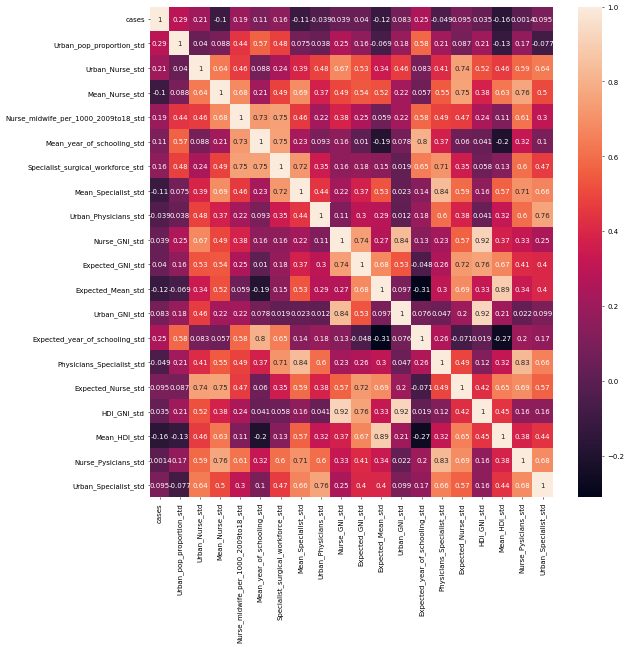

```python
import matplotlib.pyplot as plt

plt.figure(figsize=(13, 13))

_ = sns.heatmap(corr2c, annot=True)
```

```python
result_interacBest_std = smf.ols(
    'cases ~ Urban_pop_proportion_std + Urban_Nurse_std + Mean_Nurse_std + Nurse_midwife_per_1000_2009to18_std + Mean_year_of_schooling_std + Specialist_surgical_workforce_std + Mean_Specialist_std + Urban_Physicians_std + Nurse_GNI_std + Expected_GNI_std + Expected_Mean_std + Urban_GNI_std + Expected_year_of_schooling_std + Physicians_Specialist_std + Expected_Nurse_std + HDI_GNI_std + Mean_HDI_std + Nurse_Pysicians_std + Urban_Specialist_std',
    data=df_interacBest_std).fit()
# Inspect the results
print(result_interacBest_std.summary())
```

```
                            OLS Regression Results
==============================================================================
Dep. Variable:                  cases   R-squared:                       0.606
Model:                            OLS   Adj. R-squared:                  0.522
Method:                 Least Squares   F-statistic:                     7.216
Date:                Thu, 04 Jun 2020   Prob (F-statistic):           3.12e-11
Time:                        23:01:51   Log-Likelihood:                -1233.3
No. Observations:                 109   AIC:                             2507.
Df Residuals:                      89   BIC:                             2560.
Df Model:                          19
Covariance Type:            nonrobust
=======================================================================================================
                                          coef    std err          t      P>|t|      [0.025      0.975]
-------------------------------------------------------------------------------------------------------
Intercept                            1.151e+04   2102.678      5.475      0.000    7335.226    1.57e+04
Urban_pop_proportion_std             6869.9259   3310.360      2.075      0.041     292.311    1.34e+04
Urban_Nurse_std                      1.728e+04   6659.769      2.595      0.011    4051.547    3.05e+04
Mean_Nurse_std                      -2822.0788   8677.471     -0.325      0.746   -2.01e+04    1.44e+04
Nurse_midwife_per_1000_2009to18_std  3663.7531   7018.592      0.522      0.603   -1.03e+04    1.76e+04
Mean_year_of_schooling_std              -3e+04   5810.441     -5.164      0.000   -4.15e+04   -1.85e+04
Specialist_surgical_workforce_std    3.122e+04   7874.051      3.965      0.000    1.56e+04    4.69e+04
Mean_Specialist_std                 -4.028e+04   1.16e+04     -3.478      0.001   -6.33e+04   -1.73e+04
Urban_Physicians_std                -2.381e+04   4761.446     -5.000      0.000   -3.33e+04   -1.43e+04
Nurse_GNI_std                       -3.629e+04   9635.421     -3.766      0.000   -5.54e+04   -1.71e+04
Expected_GNI_std                     2.734e+04   7650.141      3.574      0.001    1.21e+04    4.25e+04
Expected_Mean_std                   -1.935e+04   8428.280     -2.296      0.024   -3.61e+04   -2603.520
Urban_GNI_std                        2.888e+04   1.27e+04      2.278      0.025    3691.477    5.41e+04
Expected_year_of_schooling_std       1.246e+04   5301.036      2.351      0.021    1929.672     2.3e+04
Physicians_Specialist_std            2.494e+04   1.07e+04      2.334      0.022    3711.909    4.62e+04
Expected_Nurse_std                   1.805e+04   8821.947      2.046      0.044     520.239    3.56e+04
HDI_GNI_std                         -2.592e+04   1.71e+04     -1.513      0.134   -5.99e+04    8113.091
Mean_HDI_std                         1.306e+04   8861.696      1.474      0.144   -4549.347    3.07e+04
Nurse_Pysicians_std                 -1.241e+04   9155.016     -1.355      0.179   -3.06e+04    5782.911
Urban_Specialist_std                 6906.6470   6079.124      1.136      0.259   -5172.442     1.9e+04
==============================================================================
Omnibus:                       51.315   Durbin-Watson:                   1.782
Prob(Omnibus):                  0.000   Jarque-Bera (JB):              192.250
Skew:                           1.597   Prob(JB):                     1.79e-42
Kurtosis:                       8.668   Cond. No.                         31.0
==============================================================================

Warnings:
[1] Standard Errors assume that the covariance matrix of the errors is correctly specified.
```

```
Columns in data are: ['Obs', 'Dep Var\nPopulation', 'Predicted\nValue', 'Std Error\nMean Predict', 'Mean ci\n95% low', 'Mean ci\n95% upp', 'Predict ci\n95% low', 'Predict ci\n95% upp', 'Residual', 'Std Error\nResidual', 'Student\nResidual', "Cook's\nD"]
```

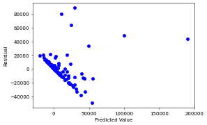

```python
st, data, ss2 = sso.summary_table(result_interacBest_std, alpha=0.05)
print("Columns in data are: %s" % ss2)
#Predicted value
x = data[:, 2]
#Residual
y = data[:, 8]
_ = plt.plot(x, y, 'o', color = 'b')
plt.xlabel('Predicted Value')
plt.ylabel('Residual')
plt.show()
```

#### Checking residual normality

To check the normality assumption, compute the residuals, plot histogram and Q-Q plot, and conduct Shapiro test.

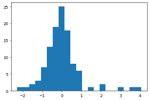

```python
_ = plt.hist(result_interacBest_std.resid_pearson, bins = 'auto')
```

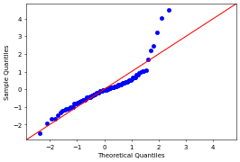

```python
fig = sm.qqplot(result_interacBest_std.resid_pearson, stats.norm, fit=True, line='45')
```

```python
stat, p = stats.shapiro(result_interacBest_std.resid_pearson)
print('Statistics=%.3f, p=%.3f' % (stat, p))
```

```
Statistics=0.866, p=0.000
```

standardize data後，normality不變

### 4.C.) with interaction(y取log->forward)

```python
df_interacBest_log = df_interac.copy()
df_interacBest_log['cases'] = np.log(df_interacBest_log['cases'])

#display(df_interacBest_stdY)
```

```python
forward_selection(input_df = df_interacBest_log,
                  depv = 'cases',
                  indepv = ['Urban_pop_proportion_std', 'Expected_year_of_schooling_std', 'Mean_year_of_schooling_std', 'Nurse_midwife_per_1000_2009to18_std', 'Physicians_per_1000_2009to18_std', 'Specialist_surgical_workforce_std', 'HDI_std', 'GNI_per_capita_std', 'Urban_Expected', 'Urban_Mean', 'Urban_Nurse', 'Urban_Physicians', 'Urban_Specialist', 'Urban_HDI', 'Urban_GNI', 'Expected_Mean', 'Expected_Nurse', 'Expected_Physicians', 'Expected_Specialist', 'Expected_HDI', 'Expected_GNI', 'Mean_Nurse', 'Mean_Physicians', 'Mean_Specialist', 'Mean_HDI', 'Mean_GNI', 'Nurse_Pysicians', 'Nurse_Specialists', 'Nurse_HDI', 'Nurse_GNI', 'Physicians_Specialist', 'Physicians_HDI', 'Physicians_GNI', 'Specialist_HDI', 'Specialist_GNI', 'HDI_GNI'])
```

[output not shown]

```python
best_subset =  ['Urban_pop_proportion_std', 'Specialist_surgical_workforce_std', 'Physicians_Specialist', 'Expected_Nurse', 'Specialist_GNI', 'Urban_Expected', 'Mean_HDI', 'Urban_Physicians', 'Nurse_Pysicians', 'Nurse_midwife_per_1000_2009to18_std', 'Physicians_per_1000_2009to18_std', 'Urban_Specialist', 'Mean_GNI', 'Mean_year_of_schooling_std', 'Physicians_GNI', 'Mean_Physicians']
modelstr = 'cases' + " ~ " + " + ".join(best_subset)
result_interacBest= smf.ols(modelstr, data=df_interacBest_log).fit()
print(result_interacBest.summary())
```

```
                            OLS Regression Results
==============================================================================
Dep. Variable:                  cases   R-squared:                       0.453
Model:                            OLS   Adj. R-squared:                  0.358
Method:                 Least Squares   F-statistic:                     4.763
Date:                Thu, 04 Jun 2020   Prob (F-statistic):           6.45e-07
Time:                        23:18:15   Log-Likelihood:                -218.75
No. Observations:                 109   AIC:                             471.5
Df Residuals:                      92   BIC:                             517.2
Df Model:                          16
Covariance Type:            nonrobust
=======================================================================================================
                                          coef    std err          t      P>|t|      [0.025      0.975]
-------------------------------------------------------------------------------------------------------
Intercept                               7.8646      0.352     22.345      0.000       7.166       8.564
Urban_pop_proportion_std                0.3786      0.302      1.253      0.213      -0.222       0.979
Specialist_surgical_workforce_std       1.1517      0.604      1.905      0.060      -0.049       2.352
Physicians_Specialist                  -0.2191      0.507     -0.432      0.667      -1.226       0.788
Expected_Nurse                          0.2839      0.427      0.665      0.508      -0.564       1.132
Specialist_GNI                         -2.0670      0.905     -2.284      0.025      -3.865      -0.269
Urban_Expected                          0.5513      0.310      1.776      0.079      -0.065       1.168
Mean_HDI                               -0.2551      0.570     -0.448      0.656      -1.387       0.877
Urban_Physicians                       -1.6240      0.487     -3.333      0.001      -2.592      -0.656
Nurse_Pysicians                         1.1302      0.434      2.604      0.011       0.268       1.992
Nurse_midwife_per_1000_2009to18_std    -0.9382      0.467     -2.007      0.048      -1.866      -0.010
Physicians_per_1000_2009to18_std        2.2743      0.795      2.861      0.005       0.695       3.853
Urban_Specialist                        0.7436      0.572      1.300      0.197      -0.393       1.880
Mean_GNI                                1.1578      0.525      2.207      0.030       0.116       2.200
Mean_year_of_schooling_std             -1.0467      0.517     -2.023      0.046      -2.074      -0.019
Physicians_GNI                          1.1007      0.659      1.670      0.098      -0.208       2.409
Mean_Physicians                        -1.8268      1.099     -1.662      0.100      -4.010       0.356
==============================================================================
Omnibus:                        3.064   Durbin-Watson:                   1.721
Prob(Omnibus):                  0.216   Jarque-Bera (JB):                2.445
Skew:                          -0.316   Prob(JB):                        0.295
Kurtosis:                       3.374   Cond. No.                         27.6
==============================================================================

Warnings:
[1] Standard Errors assume that the covariance matrix of the errors is correctly specified.
```

```
Columns in data are: ['Obs', 'Dep Var\nPopulation', 'Predicted\nValue', 'Std Error\nMean Predict', 'Mean ci\n95% low', 'Mean ci\n95% upp', 'Predict ci\n95% low', 'Predict ci\n95% upp', 'Residual', 'Std Error\nResidual', 'Student\nResidual', "Cook's\nD"]
```

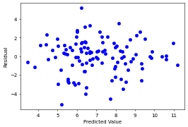

```python
st, data, ss2 = sso.summary_table(result_interacBest, alpha=0.05)
print("Columns in data are: %s" % ss2)
#Predicted value
x = data[:, 2]
#Residual
y = data[:, 8]
_ = plt.plot(x, y, 'o', color = 'b')
plt.xlabel('Predicted Value')
plt.ylabel('Residual')
plt.show()
```

#### Checking residual normality

To check the normality assumption, compute the residuals, plot histogram and Q-Q plot, and conduct Shapiro test.

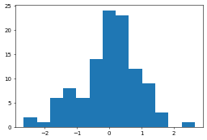

```python
_ = plt.hist(result_interacBest.resid_pearson, bins = 'auto')
```

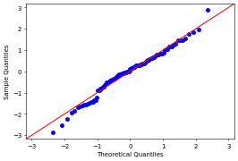

```python
fig = sm.qqplot(result_interacBest.resid_pearson, stats.norm, fit=True, line='45')
```

```python
stat, p = stats.shapiro(result_interacBest.resid_pearson)
print('Statistics=%.3f, p=%.3f' % (stat, p))
```

```
Statistics=0.983, p=0.174
```

normal, 而且adjusted r^2變低很多

## ----------------------------- 以下為結論分析 ----------------------------------

## 4.A.b. 為所有滿足常態假設的模型中，adj.R^2最高者，以下繼續分析：

```python
result_cubeBest = smf.ols(
    'cases ~ Urban_pop_proportion_std + Nurse_midwife_per_1000_2009to18_std2 + Nurse_midwife_per_1000_2009to18_std3 + HDI_std + Physicians_per_1000_2009to18_std2 + Physicians_per_1000_2009to18_std3 + Physicians_per_1000_2009to18_std + Mean_year_of_schooling_std + Nurse_midwife_per_1000_2009to18_std + GNI_per_capita_std2 + Specialist_surgical_workforce_std + Mean_year_of_schooling_std2 + Expected_year_of_schooling_std + HDI_std2',
    data=df_cubeBest).fit()
# Inspect the results
print(result_cubeBest.summary())
```

```
                            OLS Regression Results
==============================================================================
Dep. Variable:                  cases   R-squared:                       0.457
Model:                            OLS   Adj. R-squared:                  0.376
Method:                 Least Squares   F-statistic:                     5.651
Date:                Fri, 05 Jun 2020   Prob (F-statistic):           8.39e-08
Time:                        14:26:55   Log-Likelihood:                -218.35
No. Observations:                 109   AIC:                             466.7
Df Residuals:                      94   BIC:                             507.1
Df Model:                          14
Covariance Type:            nonrobust
========================================================================================================
                                           coef    std err          t      P>|t|      [0.025      0.975]
--------------------------------------------------------------------------------------------------------
Intercept                                7.3747      0.506     14.568      0.000       6.370       8.380
Urban_pop_proportion_std                 0.5231      0.279      1.872      0.064      -0.032       1.078
Nurse_midwife_per_1000_2009to18_std2     1.3994      0.594      2.358      0.020       0.221       2.578
Nurse_midwife_per_1000_2009to18_std3    -0.2920      0.183     -1.597      0.114      -0.655       0.071
HDI_std                                  1.0182      0.760      1.340      0.183      -0.490       2.527
Physicians_per_1000_2009to18_std2       -1.6037      0.464     -3.454      0.001      -2.526      -0.682
Physicians_per_1000_2009to18_std3        0.2500      0.091      2.744      0.007       0.069       0.431
Physicians_per_1000_2009to18_std         1.6226      0.696      2.331      0.022       0.240       3.005
Mean_year_of_schooling_std              -1.0369      0.496     -2.090      0.039      -2.022      -0.052
Nurse_midwife_per_1000_2009to18_std     -0.9586      0.535     -1.792      0.076      -2.021       0.103
GNI_per_capita_std2                      0.0657      0.045      1.467      0.146      -0.023       0.155
Specialist_surgical_workforce_std        0.9192      0.482      1.908      0.059      -0.037       1.876
Mean_year_of_schooling_std2             -0.5208      0.330     -1.577      0.118      -1.177       0.135
Expected_year_of_schooling_std          -0.5594      0.471     -1.187      0.238      -1.495       0.376
HDI_std2                                 0.3437      0.305      1.128      0.262      -0.261       0.949
==============================================================================
Omnibus:                        3.124   Durbin-Watson:                   1.850
Prob(Omnibus):                  0.210   Jarque-Bera (JB):                2.845
Skew:                          -0.183   Prob(JB):                        0.241
Kurtosis:                       3.702   Cond. No.                         58.4
==============================================================================

Warnings:
[1] Standard Errors assume that the covariance matrix of the errors is correctly specified.
```

according to f-test, the model is valid.

about 37.6% of total variation can be explained by these 14 independent variables, while the rest remain unexplained.

以下探討此模型中變數的關係（其他變數不變的情況）：

```
1) 平均就學年限則約以-1個標準差為分界：對平均就學年限在-1個標準差以上的國家，確診數和其呈負相關。而以下的國家，平均就學年限和確診數則呈正相關。
2) 護理師密度在平均以下的國家，其確診數會和護理師密度呈負相關，而護理師密度在正[0.39,2.79]個標準差的區間會和確診數呈正相關。但當一個國家的護理師密度高過平均約2.79個標準差之後，護理師密度愈高，其確診數就愈少。
3) 約以正0.6、正3.7個標準差為分界：醫生密度在0.6個標準差以下的國家，確診數和醫生密度呈正相關。醫生密度介於[0.6,3.7]個標準差之間的國家，確診數和其醫生密度呈負相關。最後，那些醫生密度極高的國家，其確診數和醫師密度呈正相關。
4) 都市人口比例和確診數呈正的線性關係，人口愈密集的地方，有更多群聚感染的風險，於直觀相符。
5) 專科手術人員密度也和確診數呈斜率為正的限性關係。
6) HDI則以-1.48個標準差為分界：對HDI在-1.48個標準差以上的國家確診數和其HDI呈正相關。而以下的國家，確診數和HDI則呈負相關。
7) 預期就學年限則和確診數的對數呈負的線性關係。
8) 人均國民收入在平均以上的國家，其確診數和其GNI呈正相關。平均以下的國家，其確診數和GNI則呈負相關。
```

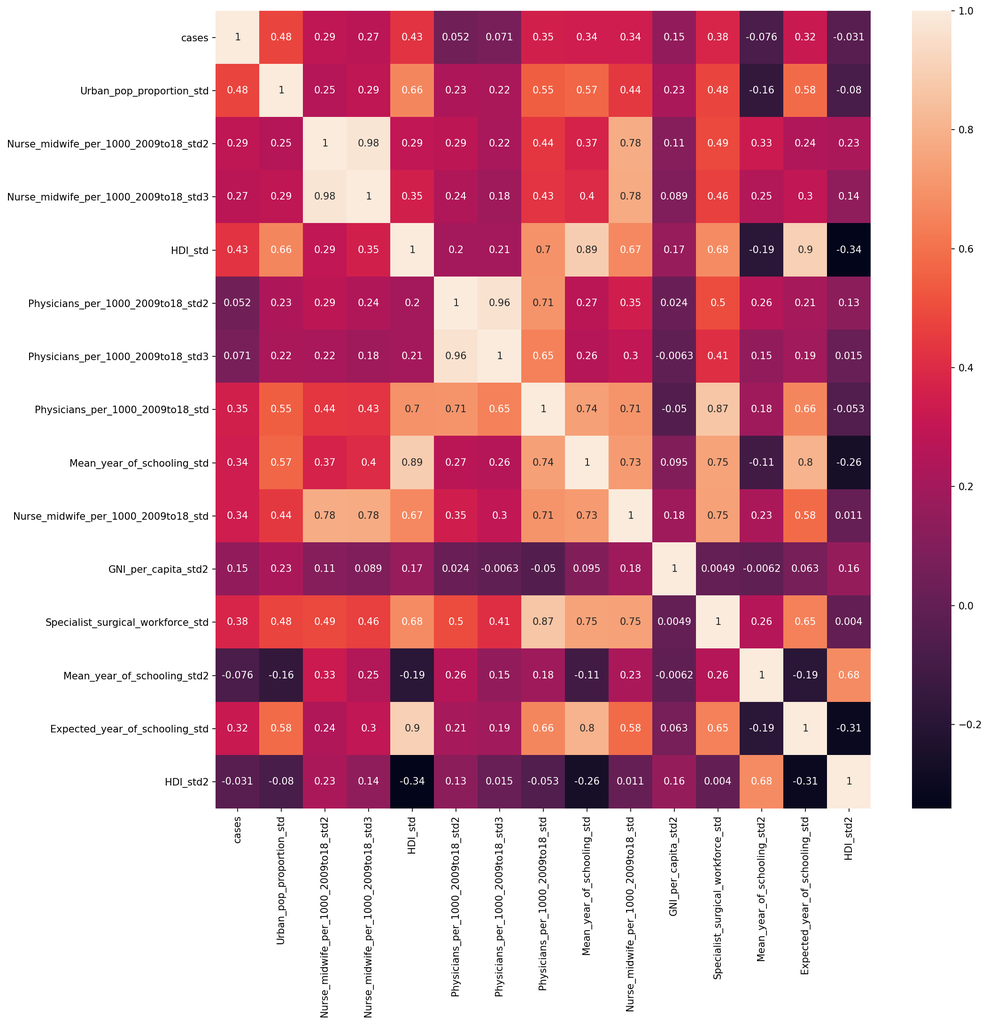

```python
corr_cb = df_cubeBest.corr()
corr_cb

plt.rcParams["figure.dpi"] = 150
plt.figure(figsize=(15, 15))
_ = sns.heatmap(corr_cb, annot=True)
```

## $\rightarrow$GNI per capita std2

並沒有和他有correlation絕對值大於0.7的變數，所以t-test的不顯著可能並不是多元共線性造成的。

## $\rightarrow$ HDI std

和他correlation絕對值大於0.7的變數有3個:

```
平均就學年限 0.183 -> 0.689
預期就學年限 0.183 -> 0.460
醫生密度 0.183 -> 0.039
```

每次都將其中一個移出模型比較新的結果：

若我們將醫生密度的一次項移出，則HDI的一次項就從不顯著變顯著了，代表是共線性造成不顯著。

## $\rightarrow$ HDI std2

並沒有和他有correlation絕對值大於0.7的變數，所以t-test的不顯著可能並不是多元共線性造成的。

## $\rightarrow$ Expected_year_of_scooling_std

和他correlation絕對值大於0.7的變數有2個:

```
HDI        0.238 -> 0.686
平均就學年限 0.238 -> 0.339
```

每次都將其中一個移出模型比較新的結果：

移除這2個變數都無法使預期就學年限變的顯著，可能與共線性無關。

## $\rightarrow$ Specialist_surgical_workforce_std

和他correlation絕對值大於0.7的變數有3個:

```
平均就學年限      0.059 -> 0.136
醫生密度         0.059 -> 0.005
護理師與助產士密度 0.059 -> 0.093
```

每次都將其中一個移出模型比較新的結果：

## $\rightarrow$ Nurse_midwife_per_1000_2009to18_std

和他correlation絕對值大於0.7的變數有5個:

```
護理師與助產士密度^2 0.076 -> 0.191
護理師與助產士密度^3 0.076 -> 0.064
醫生密度           0.076 -> 0.222
平均就學年限        0.076 -> 0.021
專科手術人員密度    0.076 -> 0.0123
```

每次都將其中一個移出模型比較新的結果：

若我們將均就學年限的一次項移出，則護理師與助產士密度的一次項就從不顯著變顯著了，代表是共線性造成不顯著。

且若我們將平均就學年限的一次項和護理師與助產士密度的三次項移出，則護理師與助產士密度的一次項就從不顯著變更顯著了，代表是共線性造成不顯著。（0.076 -> 0.018

代表護理師與助產士密度的一次項可能是受到平均就學年限的一次項和護理師與助產士密度的三次項的共線性所影響，才會不顯著。

## $\rightarrow$ Nurse_midwife_per_1000_2009to18_std3

和他correlation絕對值大於0.7的變數有2個:

```
護理師與助產士密度   0.114 -> 0.046
護理師與助產士密度^2 0.114 -> 0.062
```

每次都將其中一個移出模型比較新的結果：

若我們將護理師與助產士密度的一次項移出，則護理師與助產士密度的三次像就從不顯著變顯著了，代表是共線性造成不顯著。

雖然兩者都能使t-test的p value下降，但若同時移出兩者，p value則會不減反增。

## $\rightarrow$ Mean_year_of_scooling_std2

並沒有和他有correlation絕對值大於0.7的變數，所以t-test的不顯著可能並不是多元共線性造成的。

## $\rightarrow$ Urban_pop_proportion_std

並沒有和他有correlation絕對值大於0.7的變數，所以t-test的不顯著可能並不是多元共線性造成的。

# PART C: Simple Regression

```python
#讀取資料集
df = open('Coronavirus_1.csv')
df = pd.read_csv(df)
print('Head of dataset:')
display(df.head())
print("Tail of dataset:")
display(df.tail())
```

```
Head of dataset:
```

|  | Unnamed: 0 | region | cases | not cases | health_exp_per_capita | per_capita_exp_PPP_2016 | Physicians_per_1000_2009to18 | Nurse_midwife_per_1000_2009to18 | Specialist_surgical_workforce | HDI | Life_Expectancy | Expected_year_of_schooling | Mean_year_of_schooling | GNI_per_capita | Latitude | Density | Med_age | Urban_pop_proportion | BCG |
| --- | --- | --- | --- | --- | --- | --- | --- | --- | --- | --- | --- | --- | --- | --- | --- | --- | --- | --- | --- |
| 0 | 0 | Afghanistan | 6402 | 38736509 | 57.2 | 162.8 | 0.3 | 0.3 | 0.0 | 0.498 | 64.0 | 10.4 | 3.8 | 1824.0 | 33.0000 | 60.0 | 18.0 | 0.25 | 78.0 |
| 1 | 1 | Albania | 933 | 2877487 | 271.5 | 759.7 | 1.2 | 3.6 | 11.6 | 0.785 | 78.5 | 14.8 | 10.0 | 11886.0 | 41.1533 | 105.0 | 36.0 | 0.63 | 99.0 |
| 2 | 2 | Algeria | 6821 | 43678797 | 260.4 | 998.2 | 1.8 | 2.2 | 12.1 | 0.754 | 76.3 | 14.4 | 8.0 | 13802.0 | 28.0339 | 18.0 | 29.0 | 0.73 | 99.0 |
| 3 | 3 | Andorra | 761 | 76479 | 3834.7 | 4978.7 | 3.3 | 4.0 | 83.1 | 0.858 | 81.7 | 13.5 | 10.2 | 47574.0 | 42.5063 | 164.0 | NaN | 0.88 | NaN |
| 4 | 4 | Angola | 48 | 32644735 | 95.2 | 185.8 | 0.2 | 1.3 | NaN | 0.581 | 61.8 | 11.8 | 5.1 | 5790.0 | -11.2027 | 26.0 | 17.0 | 0.67 | 86.0 |

```
Tail of dataset:
```

|  | Unnamed: 0 | region | cases | not cases | health_exp_per_capita | per_capita_exp_PPP_2016 | Physicians_per_1000_2009to18 | Nurse_midwife_per_1000_2009to18 | Specialist_surgical_workforce | HDI | Life_Expectancy | Expected_year_of_schooling | Mean_year_of_schooling | GNI_per_capita | Latitude | Density | Med_age | Urban_pop_proportion | BCG |
| --- | --- | --- | --- | --- | --- | --- | --- | --- | --- | --- | --- | --- | --- | --- | --- | --- | --- | --- | --- |
| 190 | 190 | Sao Tome and Principe | 235 | 218073 | 105.1 | 196.9 | 0.3 | 2.3 | NaN | 0.589 | 66.8 | 12.5 | 6.3 | 2941.0 | 0.186360 | 228.0 | 19.0 | 0.74 | 96.0 |
| 191 | 191 | Yemen, Rep. | 122 | 29687092 | 72.0 | 144.5 | 0.3 | 0.7 | 0.8 | 0.452 | 65.2 | 9.0 | 3.0 | 1239.0 | 15.552727 | 56.0 | 20.0 | 0.38 | 64.0 |
| 192 | 192 | Comoros | 11 | 865685 | 59.0 | 115.8 | 0.2 | 0.9 | NaN | 0.503 | 63.9 | 11.2 | 4.8 | 1399.0 | -11.645500 | 467.0 | 20.0 | 0.29 | 94.0 |
| 193 | 193 | Tajikistan | 1322 | 9491020 | 55.7 | 208.5 | 1.7 | 5.2 | 41.7 | 0.650 | 71.2 | 11.2 | 10.4 | 3317.0 | 38.861034 | 68.0 | 22.0 | 0.27 | 99.0 |
| 194 | 194 | Lesotho | 1 | 2138798 | 85.5 | 242.7 | 0.1 | 0.7 | 0.6 | 0.520 | 54.6 | 10.6 | 6.3 | 3255.0 | -29.609988 | 71.0 | 24.0 | 0.31 | 98.0 |

#### Summary Statstics

```python
sum = df.describe()
df.describe()
```

|  | Unnamed: 0 | cases | not cases | health_exp_per_capita | per_capita_exp_PPP_2016 | Physicians_per_1000_2009to18 | Nurse_midwife_per_1000_2009to18 | Specialist_surgical_workforce | HDI | Life_Expectancy | Expected_year_of_schooling | Mean_year_of_schooling | GNI_per_capita | Latitude | Density | Med_age | Urban_pop_proportion | BCG |
| --- | --- | --- | --- | --- | --- | --- | --- | --- | --- | --- | --- | --- | --- | --- | --- | --- | --- | --- |
| count | 195.000000 | 1.950000e+02 | 1.950000e+02 | 178.000000 | 176.000000 | 177.000000 | 177.000000 | 164.000000 | 181.000000 | 180.000000 | 180.000000 | 180.000000 | 180.000000 | 195.000000 | 192.000000 | 181.000000 | 186.000000 | 133.000000 |
| mean | 97.000000 | 2.374485e+04 | 3.945440e+07 | 1081.216292 | 1457.926705 | 1.775141 | 4.186441 | 39.155488 | 0.712337 | 72.197778 | 13.297222 | 8.520556 | 18636.411111 | 19.634612 | 503.481250 | 30.585635 | 0.597258 | 90.406015 |
| std | 56.435804 | 1.132217e+05 | 1.452711e+08 | 1747.470975 | 1721.820488 | 1.587685 | 4.081699 | 41.662936 | 0.155740 | 7.799699 | 2.981553 | 3.136249 | 19904.176679 | 23.993645 | 2564.228387 | 9.093930 | 0.225059 | 12.099986 |
| min | 0.000000 | 1.000000e+00 | 3.326400e+04 | 16.400000 | 29.900000 | 0.000000 | 0.100000 | 0.000000 | 0.354000 | 52.200000 | 4.900000 | 1.500000 | 663.000000 | -40.900600 | 0.000000 | 15.000000 | 0.000000 | 26.000000 |
| 25% | 48.500000 | 1.945000e+02 | 2.017290e+06 | 79.450000 | 224.875000 | 0.300000 | 1.000000 | 2.975000 | 0.589000 | 66.675000 | 11.550000 | 6.175000 | 4113.250000 | 5.076050 | 35.750000 | 22.000000 | 0.430000 | 88.000000 |
| 50% | 97.000000 | 1.052000e+03 | 8.733792e+06 | 327.500000 | 818.050000 | 1.400000 | 2.600000 | 24.050000 | 0.747000 | 73.900000 | 13.300000 | 8.850000 | 11705.500000 | 18.109600 | 85.500000 | 30.000000 | 0.605000 | 95.000000 |
| 75% | 145.500000 | 8.021000e+03 | 2.873919e+07 | 1135.325000 | 1966.975000 | 2.900000 | 6.400000 | 65.425000 | 0.838000 | 77.600000 | 15.225000 | 11.300000 | 26117.750000 | 39.699950 | 223.500000 | 39.000000 | 0.787500 | 98.000000 |
| max | 194.000000 | 1.467820e+06 | 1.396447e+09 | 9869.700000 | 9869.700000 | 8.200000 | 20.300000 | 195.600000 | 0.953000 | 84.100000 | 22.900000 | 14.100000 | 116818.000000 | 71.706900 | 26337.000000 | 48.000000 | 0.980000 | 99.000000 |

```python
df['case_log'] = np.log(df['cases'])
```

### 8. Expected year of schooling

#### Scatter Plot

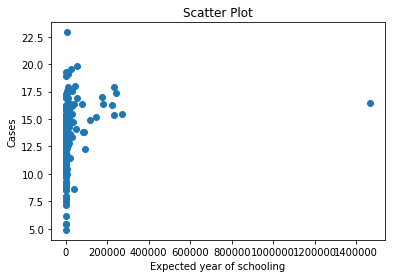

```python
#Provide convenient legend.
plt.scatter(df['cases'], df['Expected_year_of_schooling'])
plt.title('Scatter Plot')
plt.xlabel('Expected year of schooling')
plt.ylabel('Cases')
plt.show()
```

#### Regression Model

```python
result = smf.ols('cases ~ Expected_year_of_schooling', data = df).fit()

# Inspect the results
print(result.summary())
```

```
                            OLS Regression Results
==============================================================================
Dep. Variable:                  cases   R-squared:                       0.038
Model:                            OLS   Adj. R-squared:                  0.033
Method:                 Least Squares   F-statistic:                     7.026
Date:                Sun, 07 Jun 2020   Prob (F-statistic):            0.00876
Time:                        21:20:18   Log-Likelihood:                -2353.0
No. Observations:                 180   AIC:                             4710.
Df Residuals:                     178   BIC:                             4716.
Df Model:                           1
Covariance Type:            nonrobust
==============================================================================================
                                 coef    std err          t      P>|t|      [0.025      0.975]
----------------------------------------------------------------------------------------------
Intercept                  -7.656e+04   3.95e+04     -1.937      0.054   -1.55e+05    1448.650
Expected_year_of_schooling  7690.0072   2901.107      2.651      0.009    1965.019    1.34e+04
==============================================================================
Omnibus:                      352.238   Durbin-Watson:                   2.091
Prob(Omnibus):                  0.000   Jarque-Bera (JB):           120747.262
Skew:                          10.517   Prob(JB):                         0.00
Kurtosis:                     128.129   Cond. No.                         62.8
==============================================================================

Warnings:
[1] Standard Errors assume that the covariance matrix of the errors is correctly specified.
```

The regression equation is $y = -7.656e+04 + 7690.0072x$ .

#### Check for normaloty assumption

#### 1. Histogram

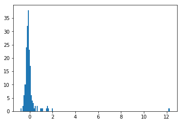

```python
_ = plt.hist(result.resid_pearson, bins = 'auto')
```

#### 2. QQ Plot

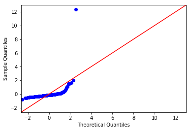

```python
fig = sm.qqplot(result.resid_pearson, stats.norm, fit=True, line='45')
```

#### 3. Shapiro Test

$H_0$ : Standardized residuals are normally distributed.  
$H_1$ : Standardized residuals are not normally distributed

```python
stat, p = stats.shapiro(result.resid_pearson)
print('Statistics=%.3f, p=%.3f' % (stat, p))
```

```
Statistics=0.267, p=0.000
```

The p value is smaller than the significant level , we can reject $H_0$ , that means the normality assumption is not satisfied.

#### Regression Model (Use log value)

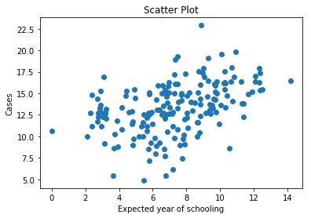

```python
#Provide convenient legend.
plt.scatter(df['case_log'], df['Expected_year_of_schooling'])
plt.title('Scatter Plot')
plt.xlabel('Expected year of schooling')
plt.ylabel('Cases')
plt.show()
```

```python
result = smf.ols('case_log ~ Expected_year_of_schooling', data = df).fit()

# Inspect the results
print(result.summary())
```

```
                            OLS Regression Results
==============================================================================
Dep. Variable:               case_log   R-squared:                       0.190
Model:                            OLS   Adj. R-squared:                  0.185
Method:                 Least Squares   F-statistic:                     41.74
Date:                Wed, 03 Jun 2020   Prob (F-statistic):           9.66e-10
Time:                        20:21:24   Log-Likelihood:                -413.30
No. Observations:                 180   AIC:                             830.6
Df Residuals:                     178   BIC:                             837.0
Df Model:                           1
Covariance Type:            nonrobust
==============================================================================================
                                 coef    std err          t      P>|t|      [0.025      0.975]
----------------------------------------------------------------------------------------------
Intercept                      2.0475      0.826      2.480      0.014       0.418       3.677
Expected_year_of_schooling     0.3915      0.061      6.461      0.000       0.272       0.511
==============================================================================
Omnibus:                        3.402   Durbin-Watson:                   1.689
Prob(Omnibus):                  0.182   Jarque-Bera (JB):                3.188
Skew:                          -0.259   Prob(JB):                        0.203
Kurtosis:                       2.605   Cond. No.                         62.8
==============================================================================

Warnings:
[1] Standard Errors assume that the covariance matrix of the errors is correctly specified.
```

#### Check for normaloty assumption

#### 1. Histogram

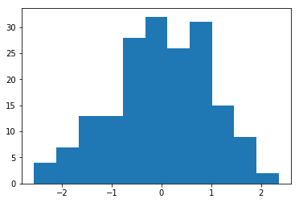

```python
_ = plt.hist(result.resid_pearson, bins = 'auto')
```

#### 2. QQ Plot

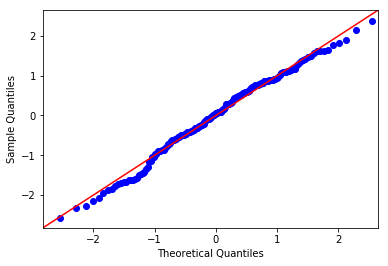

```python
fig = sm.qqplot(result.resid_pearson, stats.norm, fit=True, line='45')
```

#### 3. Shapiro Test

$H_0$ : Standardized residuals are normally distributed.  
$H_1$ : Standardized residuals are not normally distributed

```python
stat, p = stats.shapiro(result.resid_pearson)
print('Statistics=%.3f, p=%.3f' % (stat, p))
```

```
Statistics=0.988, p=0.127
```

The p value is larger than the significant level , we can't reject $H_0$ , that means the normality assumption is satisfied.

### 9. Mean year of schooling

#### Scatter Plot

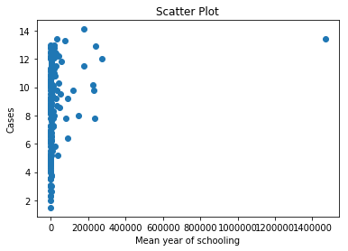

```python
#Provide convenient legend.
plt.scatter(df['cases'], df['Mean_year_of_schooling'])
plt.title('Scatter Plot')
plt.xlabel('Mean year of schooling')
plt.ylabel('Cases')
plt.show()
```

#### Regression Model

```python
result = smf.ols('cases ~ Mean_year_of_schooling', data = df).fit()

# Inspect the results
print(result.summary())
```

```
                            OLS Regression Results
==============================================================================
Dep. Variable:                  cases   R-squared:                       0.039
Model:                            OLS   Adj. R-squared:                  0.033
Method:                 Least Squares   F-statistic:                     7.152
Date:                Wed, 03 Jun 2020   Prob (F-statistic):            0.00819
Time:                        20:21:24   Log-Likelihood:                -2353.0
No. Observations:                 180   AIC:                             4710.
Df Residuals:                     178   BIC:                             4716.
Df Model:                           1
Covariance Type:            nonrobust
==========================================================================================
                             coef    std err          t      P>|t|      [0.025      0.975]
------------------------------------------------------------------------------------------
Intercept              -3.713e+04    2.5e+04     -1.484      0.140   -8.65e+04    1.23e+04
Mean_year_of_schooling  7373.1912   2757.074      2.674      0.008    1932.433    1.28e+04
==============================================================================
Omnibus:                      348.387   Durbin-Watson:                   2.106
Prob(Omnibus):                  0.000   Jarque-Bera (JB):           113517.052
Skew:                          10.299   Prob(JB):                         0.00
Kurtosis:                     124.290   Cond. No.                         26.6
==============================================================================

Warnings:
[1] Standard Errors assume that the covariance matrix of the errors is correctly specified.
```

The regression equation is $y = -3.713e+04 + 7373.1912x$ .

#### Check for normaloty assumption

#### 1. Histogram

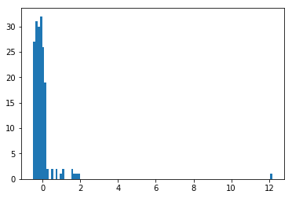

```python
_ = plt.hist(result.resid_pearson, bins = 'auto')
```

#### 2. QQ Plot

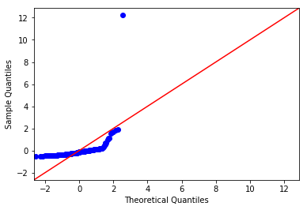

```python
fig = sm.qqplot(result.resid_pearson, stats.norm, fit=True, line='45')
```

#### 3. Shapiro Test

$H_0$ : Standardized residuals are normally distributed.  
$H_1$ : Standardized residuals are not normally distributed

```python
stat, p = stats.shapiro(result.resid_pearson)
print('Statistics=%.3f, p=%.3f' % (stat, p))
```

```
Statistics=0.279, p=0.000
```

The p value is smaller than the significant level , we can reject $H_0$ , that means the normality assumption is not satisfied.

#### Regression Model (Use log value)

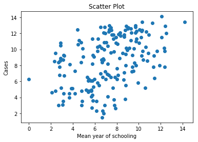

```python
#Provide convenient legend.
plt.scatter(df['case_log'], df['Mean_year_of_schooling'])
plt.title('Scatter Plot')
plt.xlabel('Mean year of schooling')
plt.ylabel('Cases')
plt.show()
```

```python
result = smf.ols('case_log ~ Mean_year_of_schooling', data = df).fit()

# Inspect the results
print(result.summary())
```

```
                            OLS Regression Results
==============================================================================
Dep. Variable:               case_log   R-squared:                       0.185
Model:                            OLS   Adj. R-squared:                  0.180
Method:                 Least Squares   F-statistic:                     40.29
Date:                Wed, 03 Jun 2020   Prob (F-statistic):           1.76e-09
Time:                        20:21:25   Log-Likelihood:                -413.89
No. Observations:                 180   AIC:                             831.8
Df Residuals:                     178   BIC:                             838.2
Df Model:                           1
Covariance Type:            nonrobust
==========================================================================================
                             coef    std err          t      P>|t|      [0.025      0.975]
------------------------------------------------------------------------------------------
Intercept                  4.1276      0.525      7.867      0.000       3.092       5.163
Mean_year_of_schooling     0.3669      0.058      6.347      0.000       0.253       0.481
==============================================================================
Omnibus:                        1.415   Durbin-Watson:                   1.698
Prob(Omnibus):                  0.493   Jarque-Bera (JB):                1.444
Skew:                          -0.146   Prob(JB):                        0.486
Kurtosis:                       2.672   Cond. No.                         26.6
==============================================================================

Warnings:
[1] Standard Errors assume that the covariance matrix of the errors is correctly specified.
```

#### Check for normaloty assumption

#### 1. Histogram

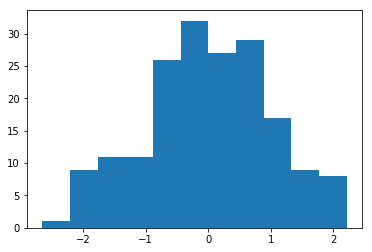

```python
_ = plt.hist(result.resid_pearson, bins = 'auto')
```

#### 2. QQ Plot

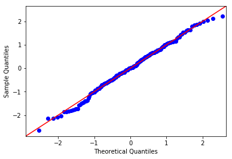

```python
fig = sm.qqplot(result.resid_pearson, stats.norm, fit=True, line='45')
```

#### 3. Shapiro Test

$H_0$ : Standardized residuals are normally distributed.  
$H_1$ : Standardized residuals are not normally distributed

```python
stat, p = stats.shapiro(result.resid_pearson)
print('Statistics=%.3f, p=%.3f' % (stat, p))
```

```
Statistics=0.992, p=0.465
```

The p value is larger than the significant level , we can't reject $H_0$ , that means the normality assumption is satisfied.

### 10. GNI per capita

#### Scatter Plot

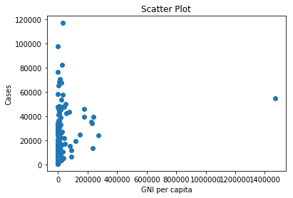

```python
#Provide convenient legend.
plt.scatter(df['cases'], df['GNI_per_capita'])
plt.title('Scatter Plot')
plt.xlabel('GNI per capita')
plt.ylabel('Cases')
plt.show()
```

#### Regression Model

```python
result = smf.ols('cases ~ GNI_per_capita', data = df).fit()

# Inspect the results
print(result.summary())
```

```
                            OLS Regression Results
==============================================================================
Dep. Variable:                  cases   R-squared:                       0.045
Model:                            OLS   Adj. R-squared:                  0.040
Method:                 Least Squares   F-statistic:                     8.481
Date:                Wed, 03 Jun 2020   Prob (F-statistic):            0.00405
Time:                        20:21:25   Log-Likelihood:                -2352.3
No. Observations:                 180   AIC:                             4709.
Df Residuals:                     178   BIC:                             4715.
Df Model:                           1
Covariance Type:            nonrobust
==================================================================================
                     coef    std err          t      P>|t|      [0.025      0.975]
----------------------------------------------------------------------------------
Intercept       2205.1814   1.18e+04      0.187      0.852   -2.11e+04    2.55e+04
GNI_per_capita     1.2606      0.433      2.912      0.004       0.406       2.115
==============================================================================
Omnibus:                      346.444   Durbin-Watson:                   2.062
Prob(Omnibus):                  0.000   Jarque-Bera (JB):           110488.690
Skew:                          10.187   Prob(JB):                         0.00
Kurtosis:                     122.653   Cond. No.                     3.73e+04
==============================================================================

Warnings:
[1] Standard Errors assume that the covariance matrix of the errors is correctly specified.
[2] The condition number is large, 3.73e+04. This might indicate that there are
strong multicollinearity or other numerical problems.
```

The regression equation is $y = 2205.1814 + 1.2606x$ .

#### Check for normaloty assumption

#### 1. Histogram

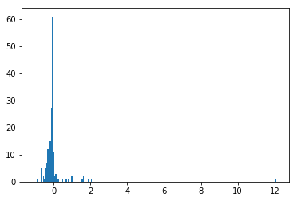

```python
_ = plt.hist(result.resid_pearson, bins = 'auto')
```

#### 2. QQ Plot

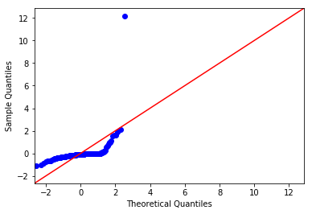

```python
fig = sm.qqplot(result.resid_pearson, stats.norm, fit=True, line='45')
```

#### 3. Shapiro Test

$H_0$ : Standardized residuals are normally distributed.  
$H_1$ : Standardized residuals are not normally distributed

```python
stat, p = stats.shapiro(result.resid_pearson)
print('Statistics=%.3f, p=%.3f' % (stat, p))
```

```
Statistics=0.278, p=0.000
```

The p value is smaller than the significant level , we can reject $H_0$ , that means the normality assumption is not satisfied.

#### Regression Model (Use log value)

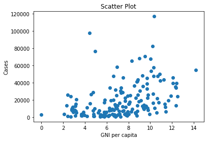

```python
#Provide convenient legend.
plt.scatter(df['case_log'], df['GNI_per_capita'])
plt.title('Scatter Plot')
plt.xlabel('GNI per capita')
plt.ylabel('Cases')
plt.show()
```

```python
result = smf.ols('case_log ~ GNI_per_capita', data = df).fit()

# Inspect the results
print(result.summary())
```

```
                            OLS Regression Results
==============================================================================
Dep. Variable:               case_log   R-squared:                       0.165
Model:                            OLS   Adj. R-squared:                  0.161
Method:                 Least Squares   F-statistic:                     35.29
Date:                Wed, 03 Jun 2020   Prob (F-statistic):           1.46e-08
Time:                        20:21:26   Log-Likelihood:                -415.98
No. Observations:                 180   AIC:                             836.0
Df Residuals:                     178   BIC:                             842.3
Df Model:                           1
Covariance Type:            nonrobust
==================================================================================
                     coef    std err          t      P>|t|      [0.025      0.975]
----------------------------------------------------------------------------------
Intercept          6.2337      0.251     24.848      0.000       5.739       6.729
GNI_per_capita  5.474e-05   9.21e-06      5.941      0.000    3.66e-05    7.29e-05
==============================================================================
Omnibus:                        1.689   Durbin-Watson:                   1.656
Prob(Omnibus):                  0.430   Jarque-Bera (JB):                1.705
Skew:                          -0.230   Prob(JB):                        0.426
Kurtosis:                       2.875   Cond. No.                     3.73e+04
==============================================================================

Warnings:
[1] Standard Errors assume that the covariance matrix of the errors is correctly specified.
[2] The condition number is large, 3.73e+04. This might indicate that there are
strong multicollinearity or other numerical problems.
```

#### Check for normaloty assumption

#### 1. Histogram

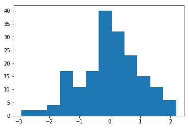

```python
_ = plt.hist(result.resid_pearson, bins = 'auto')
```

#### 2. QQ Plot

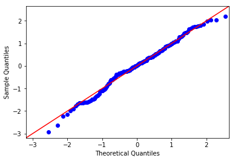

```python
fig = sm.qqplot(result.resid_pearson, stats.norm, fit=True, line='45')
```

#### 3. Shapiro Test

$H_0$ : Standardized residuals are normally distributed.  
$H_1$ : Standardized residuals are not normally distributed

```python
stat, p = stats.shapiro(result.resid_pearson)
print('Statistics=%.3f, p=%.3f' % (stat, p))
```

```
Statistics=0.989, p=0.172
```

The p value is larger than the significant level , we can't reject $H_0$ , that means the normality assumption is satisfied.